# Depmap - cancer dependency Map

12/30/2021

Adapted from Depmap vignette and “Exploiting Depmap cancer dependency data using the depmap R package” by Theo Killian and Laurent Gatto

Depmap, A “cancer dependency map”, represents the “landscape” of *in-vitro* characterization of cancer cell lines (~1700). It provides exploring data of cancer dependencies from large-scale RNAi and CRISPR-Cas9 screens. These RNAi and CRISPR-Cas9 experiments aimed to identify genes essential for cancer cell proliferation/survival. The gene’s essentiality across the different cell lines is represented as a dependency score. A lower score that a cell line is highly dependent (essential) on that gene.

*depmap* package in R imports Depmap data into:

- “rnai” (RNAi genetic dependency)
- “crispr” (CRISPR genetic dependency)
- “copyNumber” (log fold copy number)
- “TPM” (protein-coding expression)
- “RPPA” (Reverse Phase Protein Array)
- “mutationCalls” (mutation calls)
- “drug_sensitivity” (chemical dependency)
- “metadata” (metadata about all cancer cell lines)

```r
# Install depmap and ExperimentHub libraries
# Please change eval parameter to eval=TRUE in your computer

#BiocManager::install("depmap")
#BiocManager::install("ExperimentHub")
#install.packages("dplyr")
```

```r
# Load packages
# Please install missing packages if needed

library("dplyr")
```

```r
library("ggplot2")
library("viridis")
library("tibble")
library("gridExtra")
library("stringr")
library("depmap")
library("ExperimentHub")
```

Depmap data stored in the cloud via ExperimentHub. ExperimentHub is a Bioconductor’s service which stores records from experiments, publications or training courses.

We can access Depmap data using *ExperimentHub* package or directly by using *depmap* package.

```r
# An example for accessing Depmap data using *ExperimentHub* package

eh <- ExperimentHub()
```

```
## snapshotDate(): 2021-10-19
```

```r
query(eh, "depmap")
```

```
## ExperimentHub with 68 records
## # snapshotDate(): 2021-10-19
## # $dataprovider: Broad Institute
## # $species: Homo sapiens
## # $rdataclass: tibble
## # additional mcols(): taxonomyid, genome, description,
## #   coordinate_1_based, maintainer, rdatadateadded, preparerclass, tags,
## #   rdatapath, sourceurl, sourcetype
## # retrieve records with, e.g., 'object[["EH2260"]]'
##
##            title
##   EH2260 | rnai_19Q1
##   EH2261 | crispr_19Q1
##   EH2262 | copyNumber_19Q1
##   EH2263 | RPPA_19Q1
##   EH2264 | TPM_19Q1
##   ...      ...
##   EH7290 | crispr_21Q4
##   EH7291 | copyNumber_21Q4
##   EH7292 | TPM_21Q4
##   EH7293 | mutationCalls_21Q4
##   EH7294 | metadata_21Q4
```

```r
rnai <- eh[["EH3080"]]
```

```
## see ?depmap and browseVignettes('depmap') for documentation
```

```
## loading from cache
```

```r
crispr <- eh[["EH3081"]]
```

```
## see ?depmap and browseVignettes('depmap') for documentation
## loading from cache
```

```r
mutationCalls <- eh[["EH3085"]]
```

```
## see ?depmap and browseVignettes('depmap') for documentation
## loading from cache
```

```r
metadata <- eh[["EH3086"]]
```

```
## see ?depmap and browseVignettes('depmap') for documentation
## loading from cache
```

```r
TPM <- eh[["EH3084"]]
```

```
## see ?depmap and browseVignettes('depmap') for documentation
## loading from cache
```

```r
copyNumber <- eh[["EH3082"]]
```

```
## see ?depmap and browseVignettes('depmap') for documentation
## loading from cache
```

```r
drug_sensitivity_eh <- eh[["EH3087"]]
```

```
## see ?depmap and browseVignettes('depmap') for documentation
## loading from cache
```

```r
# An example for accessing Depmap data directly from *depmap* package. However, this way is much slower!!!
#rnai_depmap <- depmap::depmap_rnai()
#crispr_depmap <- depmap::depmap_crispr()
#copyNumber_depmap <- depmap::depmap_copyNumber()
#RPPA_depmap <- depmap::depmap_RPPA()
#TPM_depmap <- depmap::depmap_TPM()
#mutationCalls_depmap <- depmap::depmap_mutationCalls()
#metadata_depmap <- depmap::depmap_metadata()
#drug_sensitivity_depmap <- depmap::depmap_drug_sensitivity()
```

### Mining, manipulation and visualization

For data manipulation we will use *dplyr* package:

*`mutate()` adds new variables that are functions of existing variables

*`select()` picks variables based on their names.

*`filter()` picks cases based on their values.

*`summarise()` reduces multiple values down to a single summary.

*`arrange()` changes the ordering of the rows.

The infix operator `%>%` {pipe} is heavily used by *dplyr* package. We can use it to pass functions from the left-hand side of the operator to the first argument of the right-hand side of the operator. In the following example, the data frame iris gets passed to head():

```r
iris %>% head()
```

```
##   Sepal.Length Sepal.Width Petal.Length Petal.Width Species
## 1          5.1         3.5          1.4         0.2  setosa
## 2          4.9         3.0          1.4         0.2  setosa
## 3          4.7         3.2          1.3         0.2  setosa
## 4          4.6         3.1          1.5         0.2  setosa
## 5          5.0         3.6          1.4         0.2  setosa
## 6          5.4         3.9          1.7         0.4  setosa
```

```r
# This is equivalent to head(iris)
```

Below, the rnai dataset is selected for cell lines with “SOFT_TISSUE” in the CCLE name, and displaying a list of the highest dependency scores.

```r
## list of dependency scores
rnai %>% dplyr::select(cell_line, gene_name, dependency) %>%
          dplyr::filter(stringr::str_detect(cell_line, "SOFT_TISSUE")) %>%
          dplyr::arrange(dependency) %>%
          head(10)
```

```
## # A tibble: 10 x 3
##    cell_line          gene_name dependency
##    <chr>              <chr>          <dbl>
##  1 FUJI_SOFT_TISSUE   RPL14          -3.60
##  2 SJRH30_SOFT_TISSUE RAN            -3.41
##  3 SJRH30_SOFT_TISSUE RPL14          -3.36
##  4 SJRH30_SOFT_TISSUE RBX1           -3.31
##  5 HS729_SOFT_TISSUE  PSMA3          -3.22
##  6 SJRH30_SOFT_TISSUE RUVBL2         -3.13
##  7 KYM1_SOFT_TISSUE   RPL14          -3.03
##  8 RH41_SOFT_TISSUE   RBX1           -3.01
##  9 HS729_SOFT_TISSUE  NUTF2          -2.90
## 10 SJRH30_SOFT_TISSUE NUTF2          -2.85
```

```r
## list of dependency scores
rnai %>% dplyr::select(cell_line, gene_name, dependency) %>%
          dplyr::filter(stringr::str_detect(cell_line, "SOFT_TISSUE")) %>%
          dplyr::arrange(dependency) %>%
          head(10)
```

```
## # A tibble: 10 x 3
##    cell_line          gene_name dependency
##    <chr>              <chr>          <dbl>
##  1 FUJI_SOFT_TISSUE   RPL14          -3.60
##  2 SJRH30_SOFT_TISSUE RAN            -3.41
##  3 SJRH30_SOFT_TISSUE RPL14          -3.36
##  4 SJRH30_SOFT_TISSUE RBX1           -3.31
##  5 HS729_SOFT_TISSUE  PSMA3          -3.22
##  6 SJRH30_SOFT_TISSUE RUVBL2         -3.13
##  7 KYM1_SOFT_TISSUE   RPL14          -3.03
##  8 RH41_SOFT_TISSUE   RBX1           -3.01
##  9 HS729_SOFT_TISSUE  NUTF2          -2.90
## 10 SJRH30_SOFT_TISSUE NUTF2          -2.85
```

As the gene RPL14 appears several times in the top dependencies scores, it may make an interesting candidate target. Below, a plot of the rnai data is displayed as a histogram showing the distribution of dependency scores for gene RPL14

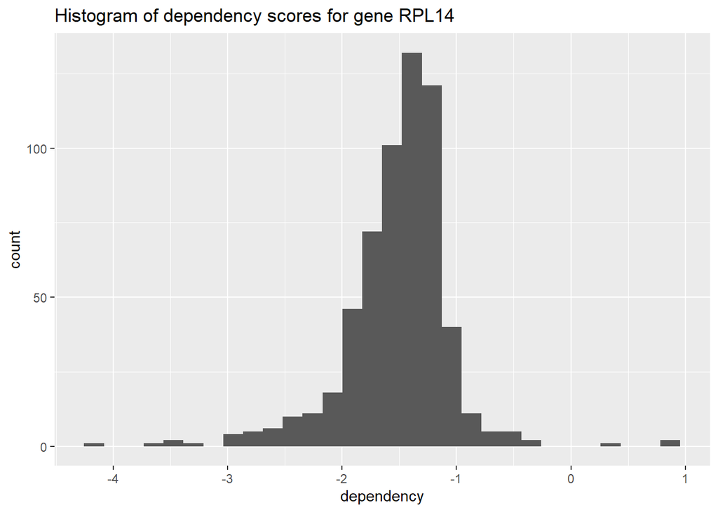

```r
## Basic histogram
rnai %>% dplyr::select(gene, gene_name, dependency) %>%
          dplyr::filter(gene_name == "RPL14") %>%
          ggplot(aes(x = dependency)) +
          geom_histogram() +
          ggtitle("Histogram of dependency scores for gene RPL14")
```

ככל שהdependency יותר שלילי ונמוך- קו התאים יותר צריך את הגן הזה, ובלעדיו הוא לא יכול לשרוד.

A more complex plot of the rnai data, as shown below involves plotting the distribution of dependency scores for gene RPL14 for each major type of cancer, while highlighting the nature of mutations of this gene in such cancer cell lines (e.g. if such are COSMIC hotspots, damaging, etc.). Notice that the plot above reflects the same overall distribution in two dimensions.

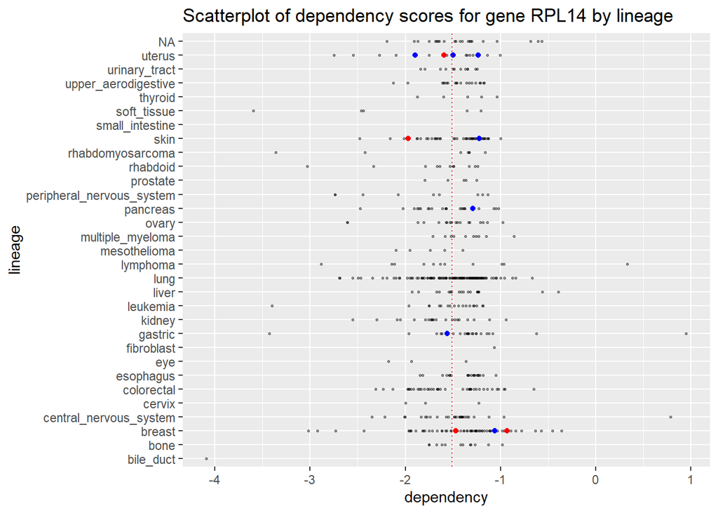

```r
meta_rnai <- metadata %>%
              dplyr::select(depmap_id, lineage) %>%
              dplyr::full_join(rnai, by = "depmap_id") %>%
              dplyr::filter(gene_name == "RPL14") %>%
              dplyr::full_join((mutationCalls %>%
                      dplyr::select(depmap_id, entrez_id,
                                    is_cosmic_hotspot, var_annotation)),
                                    by = c("depmap_id", "entrez_id"))
p1 <- meta_rnai %>%
      ggplot(aes(x = dependency, y = lineage)) +
      geom_point(alpha = 0.4, size = 0.5) +
      geom_point(data = subset(
        meta_rnai, var_annotation == "damaging"),
        color = "red") +
      geom_point(data = subset(
        meta_rnai, var_annotation == "other non-conserving"), color = "blue") +
      geom_point(data = subset(
        meta_rnai, var_annotation == "other conserving"), color = "cyan") +
      geom_point(data = subset(
        meta_rnai, is_cosmic_hotspot == TRUE), color = "orange") +
      geom_vline(xintercept=mean(meta_rnai$dependency, na.rm = TRUE),
        linetype = "dotted", color = "red") +
      ggtitle("Scatterplot of dependency scores for gene RPL14 by lineage")

p1
```

Below is a boxplot displaying expression values for gene RPL14 by lineage:

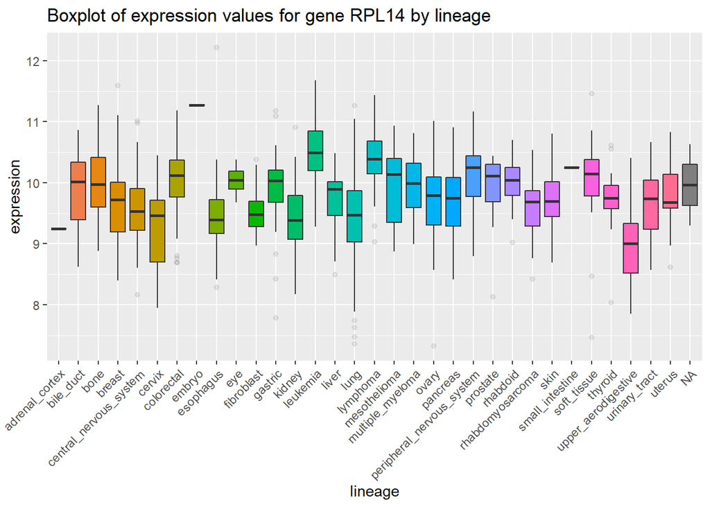

```r
metadata %>%
        dplyr::select(depmap_id, lineage) %>%
        dplyr::full_join(TPM, by = "depmap_id") %>%
        dplyr::filter(gene_name == "RPL14") %>%
        ggplot(aes(x = lineage, y = expression, fill = lineage)) +
        geom_boxplot(outlier.alpha = 0.1) +
        ggtitle("Boxplot of expression values for gene RPL14 by lineage") +
        theme(axis.text.x = element_text(angle = 45, hjust=1)) +
        theme(legend.position = "none")
```

### Home work

1. Make a scatter plot of expression vs rnai gene dependency for Rhabdomyosarcoma Sarcoma. Do for the RPL14 gene only.

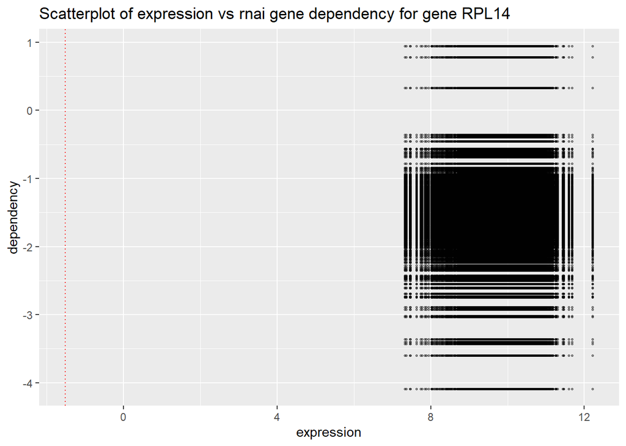

```r
# your code
p2 = metadata %>%
  dplyr::filter(primary_disease == "Sarcoma") %>%
  dplyr::filter(subtype_disease == "Rhabdomyosarcoma") %>%
  dplyr::full_join(TPM, by = "depmap_id") %>%
  dplyr::filter(gene_name == "RPL14") %>%
  dplyr::full_join(rnai, by = "gene_name") %>%
  dplyr::select(gene_name, expression, dependency) %>%
  dplyr::filter(gene_name == "RPL14")
p2 %>%
      ggplot(aes(x = expression, y = dependency))+
        geom_point(alpha = 0.4, size = 0.5) +
      geom_vline(xintercept=mean(meta_rnai$dependency,
                                 na.rm = TRUE),
                 linetype = "dotted",
                 color = "red") +
        ggtitle("Scatterplot of expression vs rnai gene dependency for gene RPL14")
```

2. Make a boxplot displaying log genomic copy number for gene RPL14 by lineage

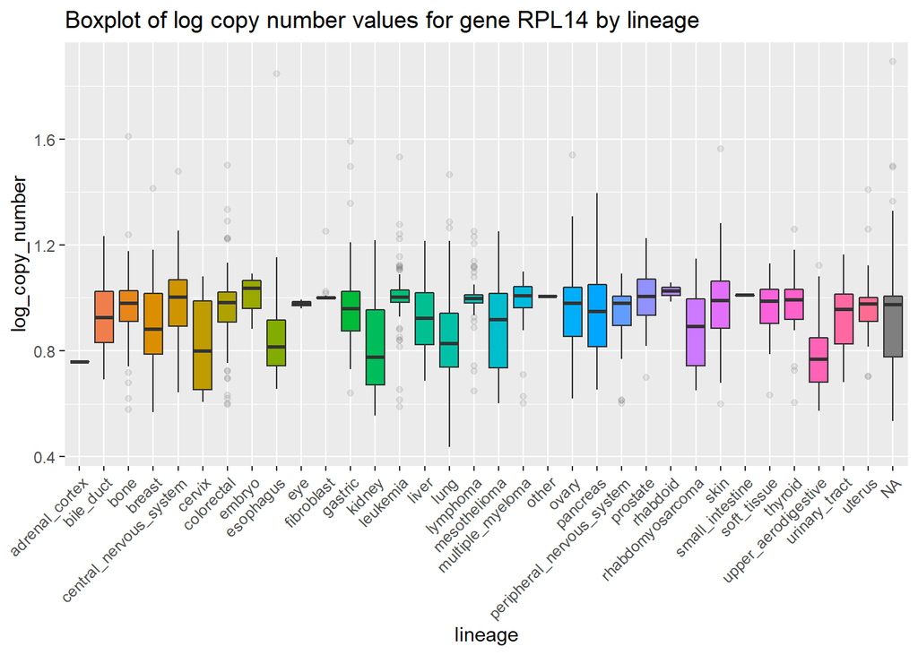

```r
# your code
copyNumber %>%
  dplyr::filter(gene_name == "RPL14") %>%
  dplyr::full_join(metadata, by = "depmap_id") %>%
  dplyr::select(depmap_id, log_copy_number, lineage) %>%
  ggplot(aes(x = lineage, y = log_copy_number, fill = lineage)) +
        geom_boxplot(outlier.alpha = 0.1) +
        ggtitle("Boxplot of log copy number values for gene RPL14 by lineage") +
        theme(axis.text.x = element_text(angle = 45, hjust=1)) +
        theme(legend.position = "none")
```